# Clustering, HDT2

Ayleen Rubio 19003, Andrés Say 19705. Andreé Toledo 18439

23/02/2021

# Clustering sobre base de datos de películas

## Análisis exploratorio de los datos

En este informe usted podrá leer los hallazgos de EDA, a continuación se muestra el resumen de los datos:

```
##        id           imdb_id            popularity           budget
##  Min.   :     5   Length:10866       Min.   : 0.00006   Min.   :        0
##  1st Qu.: 10596   Class :character   1st Qu.: 0.20758   1st Qu.:        0
##  Median : 20669   Mode  :character   Median : 0.38386   Median :        0
##  Mean   : 66064                      Mean   : 0.64644   Mean   : 14625701
##  3rd Qu.: 75610                      3rd Qu.: 0.71382   3rd Qu.: 15000000
##  Max.   :417859                      Max.   :32.98576   Max.   :425000000
##     revenue          original_title         cast             homepage
##  Min.   :0.000e+00   Length:10866       Length:10866       Length:10866
##  1st Qu.:0.000e+00   Class :character   Class :character   Class :character
##  Median :0.000e+00   Mode  :character   Mode  :character   Mode  :character
##  Mean   :3.982e+07
##  3rd Qu.:2.400e+07
##  Max.   :2.782e+09
##    director           tagline            keywords           overview
##  Length:10866       Length:10866       Length:10866       Length:10866
##  Class :character   Class :character   Class :character   Class :character
##  Mode  :character   Mode  :character   Mode  :character   Mode  :character
##
##
##
##     runtime         genres          production_companies release_date
##  Min.   :  0.0   Length:10866       Length:10866         Length:10866
##  1st Qu.: 90.0   Class :character   Class :character     Class :character
##  Median : 99.0   Mode  :character   Mode  :character     Mode  :character
##  Mean   :102.1
##  3rd Qu.:111.0
##  Max.   :900.0
##    vote_count      vote_average    release_year    budget_adj
##  Min.   :  10.0   Min.   :1.500   Min.   :1960   Min.   :        0
##  1st Qu.:  17.0   1st Qu.:5.400   1st Qu.:1995   1st Qu.:        0
##  Median :  38.0   Median :6.000   Median :2006   Median :        0
##  Mean   : 217.4   Mean   :5.975   Mean   :2001   Mean   : 17551040
##  3rd Qu.: 145.8   3rd Qu.:6.600   3rd Qu.:2011   3rd Qu.: 20853251
##  Max.   :9767.0   Max.   :9.200   Max.   :2015   Max.   :425000000
##   revenue_adj
##  Min.   :0.000e+00
##  1st Qu.:0.000e+00
##  Median :0.000e+00
##  Mean   :5.136e+07
##  3rd Qu.:3.370e+07
##  Max.   :2.827e+09
```

En el siguiente cuadro se muestra el tipo de dato de cada variable:

```
## 'data.frame':    10866 obs. of  21 variables:
##  $ id                  : int  135397 76341 262500 140607 168259 281957 87101 286217 211672 150540 ...
##  $ imdb_id             : chr  "tt0369610" "tt1392190" "tt2908446" "tt2488496" ...
##  $ popularity          : num  32.99 28.42 13.11 11.17 9.34 ...
##  $ budget              : int  150000000 150000000 110000000 200000000 190000000 135000000 155000000 108000000 74000000 175000000 ...
##  $ revenue             : num  1.51e+09 3.78e+08 2.95e+08 2.07e+09 1.51e+09 ...
##  $ original_title      : chr  "Jurassic World" "Mad Max: Fury Road" "Insurgent" "Star Wars: The Force Awakens" ...
##  $ cast                : chr  "Chris Pratt|Bryce Dallas Howard|Irrfan Khan|Vincent D'Onofrio|Nick Robinson" "Tom Hardy|Charlize Theron|Hugh Keays-Byrne|Nicholas Hoult|Josh Helman" "Shailene Woodley|Theo James|Kate Winslet|Ansel Elgort|Miles Teller" "Harrison Ford|Mark Hamill|Carrie Fisher|Adam Dr…
##  $ homepage            : chr  "http://www.jurassicworld.com/" "http://www.madmaxmovie.com/" "http://www.thedivergentseries.movie/#insurgent" "http://www.starwars.com/films/star-wars-episode-vii" ...
##  $ director            : chr  "Colin Trevorrow" "George Miller" "Robert Schwentke" "J.J. Abrams" ...
##  $ tagline             : chr  "The park is open." "What a Lovely Day." "One Choice Can Destroy You" "Every generation has a story." ...
##  $ keywords            : chr  "monster|dna|tyrannosaurus rex|velociraptor|island" "future|chase|post-apocalyptic|dystopia|australia" "based on novel|revolution|dystopia|sequel|dystopic future" "android|spaceship|jedi|space opera|3d" ...
##  $ overview            : chr  "Twenty-two years after the events of Jurassic Park, Isla Nublar now features a fully functioning dinosaur theme"| __truncated__ "An apocalyptic story set in the furthest reaches of our planet, in a stark desert landscape where humanity is b"| __truncated__ "Beatrice…
##  $ runtime             : int  124 120 119 136 137 156 125 141 91 94 ...
##  $ genres              : chr  "Action|Adventure|Science Fiction|Thriller" "Action|Adventure|Science Fiction|Thriller" "Adventure|Science Fiction|Thriller" "Action|Adventure|Science Fiction|Fantasy" ...
##  $ production_companies: chr  "Universal Studios|Amblin Entertainment|Legendary Pictures|Fuji Television Network|Dentsu" "Village Roadshow Pictures|Kennedy Miller Productions" "Summit Entertainment|Mandeville Films|Red Wagon Entertainment|NeoReel" "Lucasfilm|Truenorth Productions|Bad Robot" ...
##  $ release_date        : chr  "6/9/15" "5/13/15" "3/18/15" "12/15/15" ...
##  $ vote_count          : int  5562 6185 2480 5292 2947 3929 2598 4572 2893 3935 ...
##  $ vote_average        : num  6.5 7.1 6.3 7.5 7.3 7.2 5.8 7.6 6.5 8 ...
##  $ release_year        : int  2015 2015 2015 2015 2015 2015 2015 2015 2015 2015 ...
##  $ budget_adj          : num  1.38e+08 1.38e+08 1.01e+08 1.84e+08 1.75e+08 ...
##  $ revenue_adj         : num  1.39e+09 3.48e+08 2.72e+08 1.90e+09 1.39e+09 ...
```

### Preprocesamiento de datos

En primer lugar, es necesario hacer un complete cases para ignorar aquellos casos en los que las variables se encuentren como N/A.

Para saber la mejor cantidad de clusters a utilizar, se hará lo siguiente:

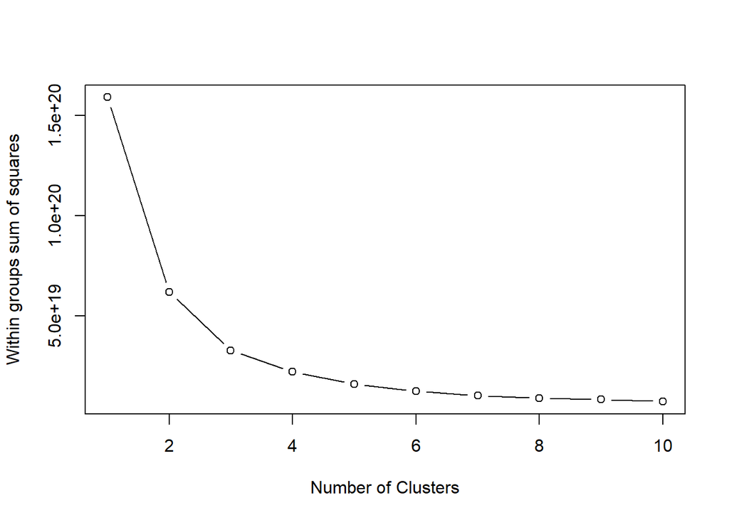

Puede observarse en el gráfico que el codo se encuentra en el valor 3, por lo que esta es la cantidad adecuada de clusters que se deben utilizar.

## Agrupamiento por medio de k-means

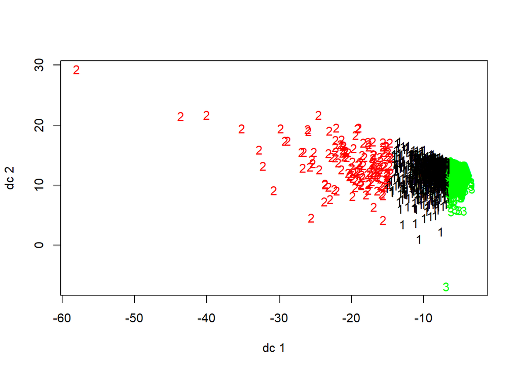

Se puede observar cómo es que se han dividido los tres grupos, siendo el primero el de color negro, el segundo el de color rojo y el tercero el de color verde. Al momento de cambiar de un grupo a otro, puede haber una ligera confusión ya que algunos objetos de un grupo, se encuentran en otro.

## Agrupamiento por medio de clustering jerárquico

```
##
## Call:
## hclust(d = dist(datos[, 1:6]))
##
## Cluster method   : complete
## Distance         : euclidean
## Number of objects: 10866
```

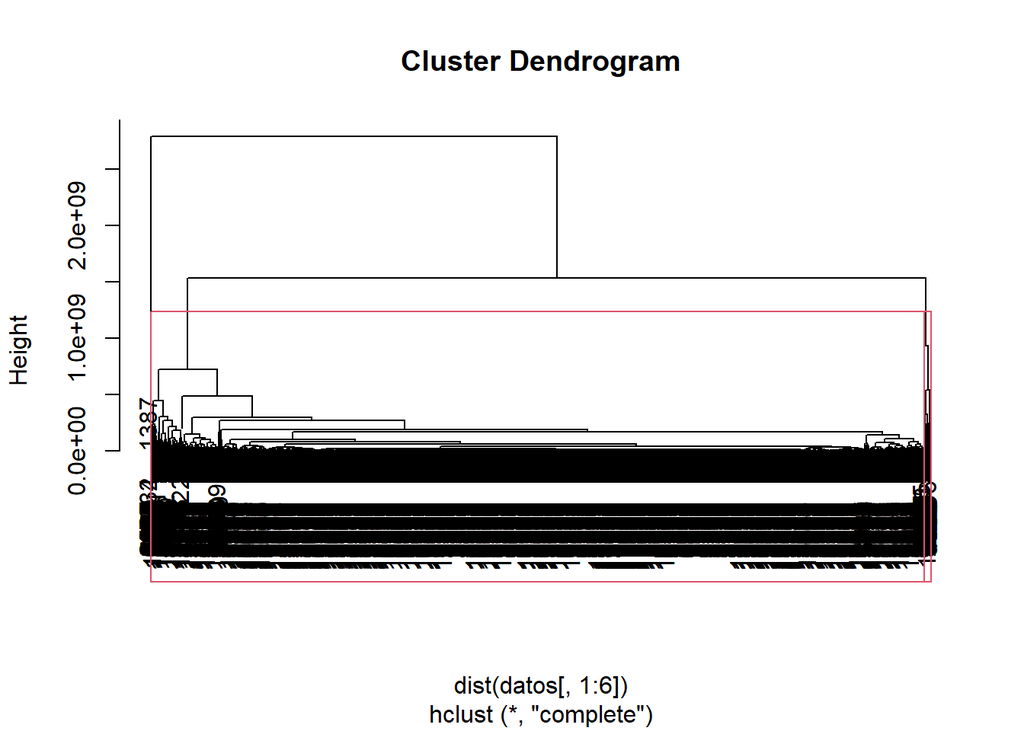

Este diagrama es más complicado de interpretar, ya que cuenta con 10866 objetos, razón por la cual no se logra observar el último grupo en el que se ha dividido.

## Fuzzy C-means

```r
fcm<-cmeans(datos[,1:6],3)
datos$FCGrupos<-fcm$cluster
datos<-cbind(datos,fcm$membership)
```

## Mixture of gaussians

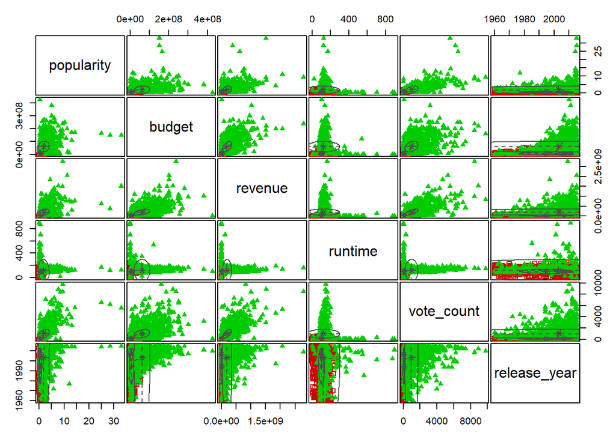

Es este gráfico puede observarse cómo es que para cada combinación de variables cuál es la combinación de los grupos

## Calidad del agrupamiento

### K-means

```
## [1] 0.8283339
```

### Cluster jerárquico

```
## [1] 0.9121253
```

### Fuzzy C-means

```
## [1] 0.8200381
```

### Mixture of gaussians

```
## [1] 0.1627272
```

Según los valores obtenidos, el que cuenta con la mayor silueta es el cluster jerárquico con un valor de 0.912, por esta razón, se utilizará este método de agrupamiento para explorar e interpretar los grupos.

## Visualizar el cluster jerárquico

#Se aplico el agrupamiento Jerárquico, denograma sin recorte de filas.

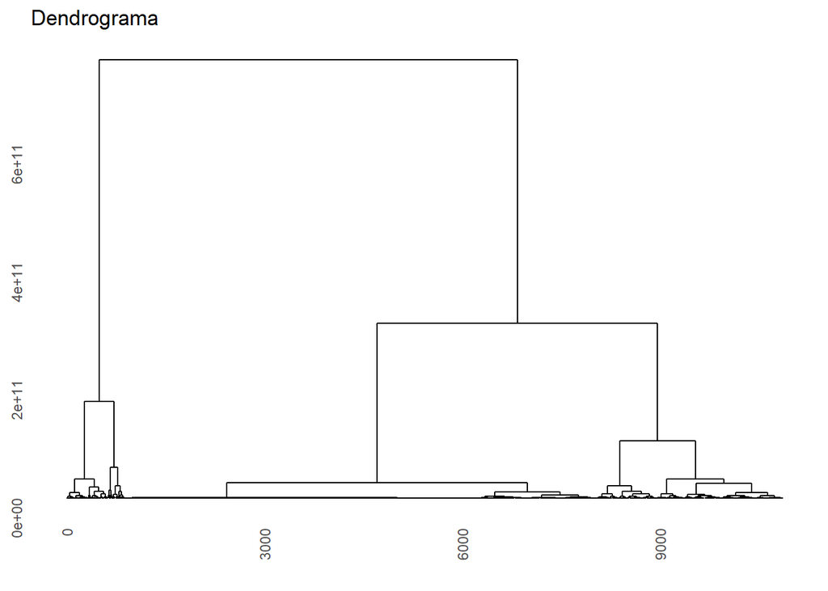

## Ejemplo de agrupamiento Jerárquico de Popularidad y presupuesto

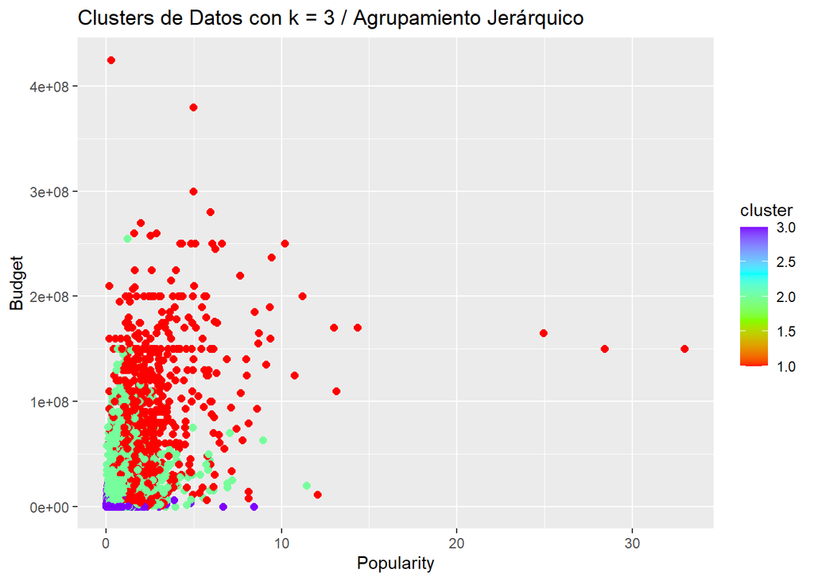

Los grupos generados son los siguientes:

```
##       popularity    budget    revenue runtime vote_count release_year grupo
## 1      32.985763 150000000 1513528810     124       5562         2015     2
## 5       9.335014 190000000 1506249360     137       2947         2015     2
## 9       7.404165  74000000 1156730962      91       2893         2015     2
## 10      6.326804 175000000  853708609      94       3935         2015     2
## 11      6.200282 245000000  880674609     148       3254         2015     2
## 15      5.944927 280000000 1405035767     141       4304         2015     2
## 20      5.476958 160000000  650523427     136       2380         2015     2
## 26      4.566713 150000000  682330139     131       2349         2015     2
## 630    24.949134 165000000  621752480     169       6498         2014     2
## 631    14.311205 170000000  773312399     121       5612         2014     2
## 632    12.971027 170000000  714766572     136       3848         2014     2
## 634    10.739009 125000000  752100229     123       3590         2014     2
## 635    10.174599 250000000  955119788     144       3110         2014     2
## 636     8.691294 165000000  652105443     102       4185         2014     2
```

[output cut: 183 more lines]

```
##       popularity    budget    revenue runtime vote_count release_year grupo
## 1      32.985763 150000000 1513528810     124       5562         2015     2
## 5       9.335014 190000000 1506249360     137       2947         2015     2
## 9       7.404165  74000000 1156730962      91       2893         2015     2
## 10      6.326804 175000000  853708609      94       3935         2015     2
## 11      6.200282 245000000  880674609     148       3254         2015     2
## 15      5.944927 280000000 1405035767     141       4304         2015     2
## 20      5.476958 160000000  650523427     136       2380         2015     2
## 26      4.566713 150000000  682330139     131       2349         2015     2
## 630    24.949134 165000000  621752480     169       6498         2014     2
## 631    14.311205 170000000  773312399     121       5612         2014     2
## 632    12.971027 170000000  714766572     136       3848         2014     2
## 634    10.739009 125000000  752100229     123       3590         2014     2
## 635    10.174599 250000000  955119788     144       3110         2014     2
## 636     8.691294 165000000  652105443     102       4185         2014     2
```

[output cut: 183 more lines]

```
##      popularity    budget    revenue runtime vote_count release_year grupo
## 4     11.173104 200000000 2068178225     136       5292         2015     2
## 1387   9.432768 237000000 2781505847     162       8458         2009     2
## 5232   4.355219 200000000 1845034188     194       4654         1997     2
##      gruposHC
## 4           3
## 1387        3
## 5232        3
```

### Medidas de tenencia central de Grupo 1

```
##    popularity          budget             revenue             runtime
##  Min.   : 0.4368   Min.   : 10500000   Min.   :5.861e+08   Min.   : 88.0
##  1st Qu.: 2.7898   1st Qu.:113500000   1st Qu.:7.086e+08   1st Qu.:106.2
##  Median : 4.1540   Median :150000000   Median :7.914e+08   Median :130.5
##  Mean   : 5.0969   Mean   :155270408   Mean   :8.537e+08   Mean   :128.5
##  3rd Qu.: 5.9957   3rd Qu.:200000000   3rd Qu.:9.503e+08   3rd Qu.:143.8
##  Max.   :32.9858   Max.   :380000000   Max.   :1.520e+09   Max.   :201.0
##    vote_count    release_year      grupo      gruposHC
##  Min.   : 201   Min.   :1977   Min.   :2   Min.   :1
##  1st Qu.:2169   1st Qu.:2005   1st Qu.:2   1st Qu.:1
##  Median :3126   Median :2010   Median :2   Median :1
##  Mean   :3396   Mean   :2008   Mean   :2   Mean   :1
##  3rd Qu.:4214   3rd Qu.:2013   3rd Qu.:2   3rd Qu.:1
##  Max.   :9767   Max.   :2015   Max.   :2   Max.   :1
```

### Medidas de tenencia central de Grupo 2

```
##    popularity            budget             revenue             runtime
##  Min.   : 0.000065   Min.   :        0   Min.   :        0   Min.   :  0.0
##  1st Qu.: 0.206468   1st Qu.:        0   1st Qu.:        0   1st Qu.: 90.0
##  Median : 0.380414   Median :        0   Median :        0   Median : 99.0
##  Mean   : 0.603787   Mean   : 13290234   Mean   : 31802914   Mean   :101.8
##  3rd Qu.: 0.699570   3rd Qu.: 15000000   3rd Qu.: 22201636   3rd Qu.:111.0
##  Max.   :28.419936   Max.   :425000000   Max.   :611899420   Max.   :900.0
##    vote_count      release_year      grupo          gruposHC
##  Min.   :  10.0   Min.   :1960   Min.   :1.000   Min.   :2
##  1st Qu.:  17.0   1st Qu.:1995   1st Qu.:3.000   1st Qu.:2
##  Median :  37.0   Median :2006   Median :3.000   Median :2
##  Mean   : 186.8   Mean   :2001   Mean   :2.835   Mean   :2
##  3rd Qu.: 139.0   3rd Qu.:2011   3rd Qu.:3.000   3rd Qu.:2
##  Max.   :7375.0   Max.   :2015   Max.   :3.000   Max.   :2
```

### Medidas de tenencia central de Grupo 3

```
##    popularity         budget             revenue             runtime
##  Min.   : 4.355   Min.   :200000000   Min.   :1.845e+09   Min.   :136
##  1st Qu.: 6.894   1st Qu.:200000000   1st Qu.:1.957e+09   1st Qu.:149
##  Median : 9.433   Median :200000000   Median :2.068e+09   Median :162
##  Mean   : 8.320   Mean   :212333333   Mean   :2.232e+09   Mean   :164
##  3rd Qu.:10.303   3rd Qu.:218500000   3rd Qu.:2.425e+09   3rd Qu.:178
##  Max.   :11.173   Max.   :237000000   Max.   :2.782e+09   Max.   :194
##    vote_count    release_year      grupo      gruposHC
##  Min.   :4654   Min.   :1997   Min.   :2   Min.   :3
##  1st Qu.:4973   1st Qu.:2003   1st Qu.:2   1st Qu.:3
##  Median :5292   Median :2009   Median :2   Median :3
##  Mean   :6135   Mean   :2007   Mean   :2   Mean   :3
##  3rd Qu.:6875   3rd Qu.:2012   3rd Qu.:2   3rd Qu.:3
##  Max.   :8458   Max.   :2015   Max.   :2   Max.   :3
```

A partir de este trabajo se podría identificar qué objetos son miembros de cada grupo para poder investigar las películas que han tenido valores altos tanto en popularidad, presupuesto y ganancias, por ejemplo, de la misma manera se podría identificar a los que cuentan con los valores más bajos.